# Logistic Regression: Script Lecture 6

Michaela Kreyenfeld (in collaboration with Cristina Samper)

Fall 2019

# 1 Why do I have to calculate predicted probabilities?

There are different options to present the results from the logistic regression model. The Odds Ratio (OR), which you got to know in Lecture 2, is among the most common ones. The drawback of this representation is that odds are not very accessible to the wider audience. When you are asked to present your findings, for example, to policy makers or journalists, OR may not be appreciated. An alternative is to present the results in terms of predicted probabilities.

You may ask yourself why one would bother with the OR in the first place, when the predicted probabilities are so much easier to interpret. However, the predicted probabilities also have their downsides. The main drawback is that there is not one single predicted probability; but many predicted probabilities from one model given different covariate constellations. We will explain the issue below in more detail.

# 2 Manual calculation of the predicted probabilities

## 2.1 Predicted probabilities in a model with one continuous covariate

Imagine that we are interested in people’s attitudes towards same sex (male) couples raising children. The outcome variable is a dummy coded with 1 as ‘agrees’ and 0 otherwise. We include only one covariate, which is the respondent’s age. Table 1 reports the results from the Model. The Model displays the beta coefficient from the model.

```r
OUTPUT01 <- glm(DEP~ AGE, data=SUBSET02, family=binomial())
```

**Table 1**: R-Output (Model 1)

```r
summary(OUTPUT01)
```

```
##
## Call:
## glm(formula = DEP ~ AGE, family = binomial(), data = SUBSET02)
##
## Deviance Residuals:
##     Min       1Q   Median       3Q      Max
## -1.9369  -1.0691   0.6762   0.9630   1.8383
##
## Coefficients:
##              Estimate Std. Error z value Pr(>|z|)
## (Intercept)  2.497216   0.140500   17.77   <2e-16 ***
## AGE         -0.043769   0.002655  -16.48   <2e-16 ***
## ---
## Signif. codes:  0 '***' 0.001 '**' 0.01 '*' 0.05 '.' 0.1 ' ' 1
##
## (Dispersion parameter for binomial family taken to be 1)
##
##     Null deviance: 3261.5  on 2396  degrees of freedom
## Residual deviance: 2948.9  on 2395  degrees of freedom
## AIC: 2952.9
##
## Number of Fisher Scoring iterations: 4
```

Source: ISSP 2012, Spain

In order to generate the predicted probabilities from this model, we need to rearrange the formula of the logistic regression. The formula is:

((1))

$$LN(\frac{P(x)}{1-P(x)})=b_0 + b_1x_1$$

We need to rearrange this formula to be able to solve for $P(x)$ (we want $P(x)$ to stand alone on the left side of the equation). Some algebra is needed to achieve this; you can find the details reported in the Appendix of this document. Important is only that after rearranging, the equation is as follows:

((2))

$$P(x)= \frac{1}{1+e^{-(b_0 + b_1x_1)}}$$

$P(x)$ stands for the predicted probability. The little “e” in the equation is Euler’s number (which you also know as “exp”). $b_{0}$ is the constant which is 2.497216 and $b_{1}$ is the coefficient for age (-0.043769). You may plug these values into the formula and obtain different predicted values for different values of AGE (x_1). Table 2 provides an extract of the first 10 cases of the data set. For these cases, I have manually calculated the predicted probabilities. Table 3 shows how I inserted the equation into Excel.

**Table 2**: Predicted probabilities for the first 10 cases in the data set

```r
DATAF
```

```
##       ID AGE  P(X)
##  [1,]  1  24 0.809
##  [2,]  2  50 0.577
##  [3,]  3  74 0.323
##  [4,]  4  85 0.227
##  [5,]  5  29 0.773
##  [6,]  6  36 0.715
##  [7,]  7  48 0.598
##  [8,]  8  19 0.841
##  [9,]  9  31 0.758
## [10,] 10  52 0.555
```

**Table 3**: Calculation of the predicted probabilities in Excel

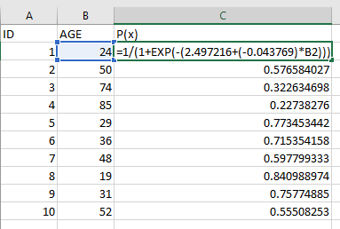

You can easily see from Table 2 that there are different predicted probabilities for different ages. Thus, there is one coefficient for AGE (and one OR), but there are many predicted probabilities – varying continuously by AGE. Thus, we cannot provide a single value, but we have to grapple with a lot of values. One option is to plot these different values.

```r
SUBSET02$PREDICT <- 1/(1+exp(-(2.497216+(-0.043769)*SUBSET02$AGE)))

head(SUBSET02[c("AGE","PREDICT")])
```

```
## # A tibble: 6 x 2
##         AGE   PREDICT
##   <dbl+lbl> <dbl+lbl>
## 1        24     0.809
## 2        50     0.577
## 3        74     0.323
## 4        85     0.227
## 5        29     0.773
## 6        36     0.715
```

**Figure 1**: Predicted probabilities from Model 1

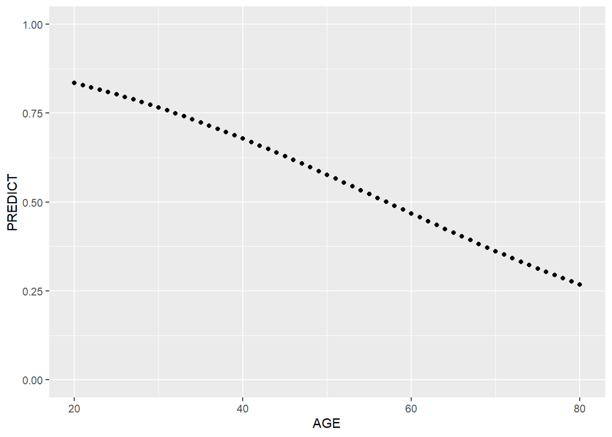

```r
ggplot(SUBSET02, aes(AGE, PREDICT)) + geom_point() + xlim(20,80) + ylim(0, 1)
```

## 2.2 Predicted probabilities in R

In “real life”, we would not manually calculate the predicted probabilities. Instead, we would let R do this. In order to calculate the predicted probabilities for a variable, you need to specify the values of your x-variables (in this case AGE). For example, I would like to get the predicted values for the ages 20, 30, 40, 50, 60 and 70. The respective command and the output are listed below:

```r
NEWDATA <- data.frame(AGE=c(20,30, 40, 50, 60, 70))
NEWDATA$PP <- predict(OUTPUT01, newdata=NEWDATA, type="response")
NEWDATA
```

```
##   AGE        PP
## 1  20 0.8350496
## 2  30 0.7656951
## 3  40 0.6784103
## 4  50 0.5765900
## 5  60 0.4678209
## 6  70 0.3620264
```

Please note that for this option you have to specify values of each of the variables you included in the model otherwise the predict function in R will not know what values to give to the other variables in the model and you will get an error message.

Then it is possible to plot the results like we did above (see Figure 2). How can we interpret Figure 2? The easiest solution is to discuss the probabilities for the different ages. For example: at age 20, about 83 % of the population is in favor of same sex couples raising children. This value decreases to 36 % at age 70.

**Figure 2**: Predicted probabilities from model

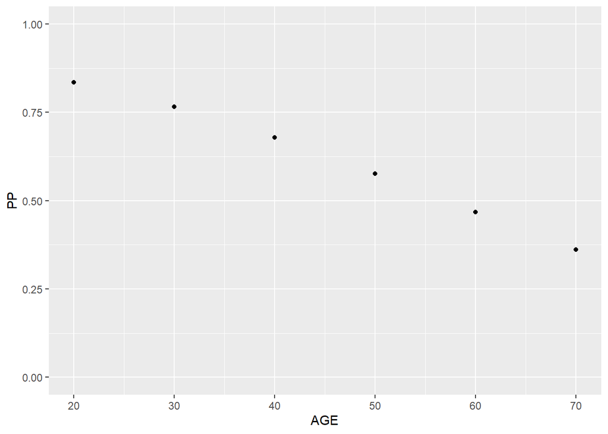

```r
ggplot(NEWDATA, aes(AGE, PP)) + geom_point() + xlim(20,70) + ylim(0, 1)
```

## 2.3 Models with more than one covariate

In most cases, you will have more than just one covariate. For example, you may control for AGE and SEX. The results of such a model are listed in Table 4. The predicted probabilities are listed in Table 5 and plotted in Figure 3. While the graphs are still instructive, you can easily see that the figure gets more complex with each additional variable that you enter into the equation. A solution to this “problem” is to calculate margins at the means of the other covariates. This strategy will be explained in the next step.

```r
OUTPUT02 <- glm(DEP ~ AGE + Gender, data=SUBSET02, family=binomial())
```

**Table 4**: R-Output (Model 2)

```r
summary(OUTPUT02)
```

```
##
## Call:
## glm(formula = DEP ~ AGE + Gender, family = binomial(), data = SUBSET02)
##
## Deviance Residuals:
##     Min       1Q   Median       3Q      Max
## -2.0589  -1.0436   0.6734   0.9496   1.9555
##
## Coefficients:
##                 Estimate Std. Error z value Pr(>|z|)
## (Intercept)     2.254407   0.145048  15.542  < 2e-16 ***
## AGE            -0.044518   0.002679 -16.616  < 2e-16 ***
## Gender1_female  0.538610   0.089637   6.009 1.87e-09 ***
## ---
## Signif. codes:  0 '***' 0.001 '**' 0.01 '*' 0.05 '.' 0.1 ' ' 1
##
## (Dispersion parameter for binomial family taken to be 1)
##
##     Null deviance: 3261.5  on 2396  degrees of freedom
## Residual deviance: 2912.3  on 2394  degrees of freedom
## AIC: 2918.3
##
## Number of Fisher Scoring iterations: 4
```

One possibility in this case would be to calculate the predicted probabilities for the whole data set and then plot the variables of interest:

```r
SUBSET02$PREDICT <- predict(OUTPUT02, type="response")
```

Note that the command `predict(OUTPUT02, type="response")` is equivalent to the command we saw in class `plogis(predict(OUTPUT02))`. If you do not specify `type=response` in the `predict` command then it predicts the values for the linear combination of the variables. The `plogis` command corresponds to the distribution function of the logistic, or the equation above (2).

**Table 5**: Predicted probabilities for selected cases

```r
head(SUBSET02[c("AGE","Gender","PREDICT")])
```

```
## # A tibble: 6 x 3
##         AGE Gender   PREDICT
##   <dbl+lbl> <fct>      <dbl>
## 1        24 0_male     0.766
## 2        50 1_female   0.638
## 3        74 0_male     0.261
## 4        85 0_male     0.178
## 5        29 0_male     0.724
## 6        36 1_female   0.767
```

**Figure 3**: Predicted probabilities from Model 2

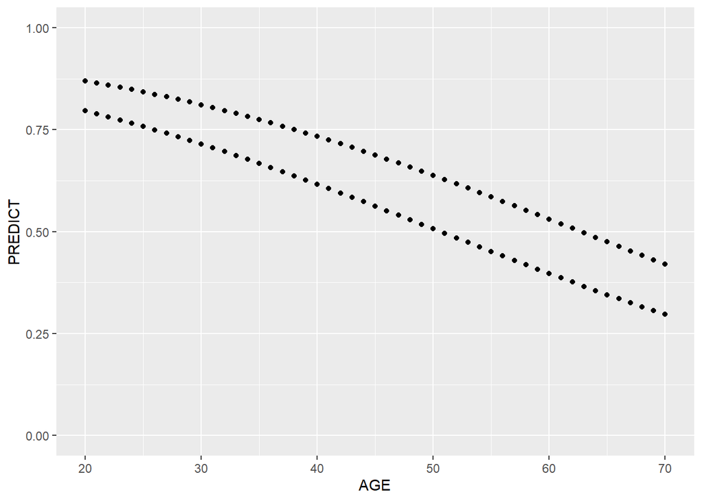

```r
ggplot(SUBSET02, aes(AGE, PREDICT)) + geom_point() + xlim(20,70) + ylim(0, 1)
```

# 3 Margins (at the means of the other covariates)

## 3.1 Manual calculation (one continuous, one categorical variable)

A solution to the abovementioned “problem” is to calculate margins. “A margin is a statistic based on a fitted model … in which some of or all the covariates are fixed” (STATA Corp 2011: 1034). Margins are the same as “predictive margins” or “adjusted predictions”. In class you saw the option of using the `Margins()` package in R. Here we will show you how to calculate the margins manually for the case when you want to set all other covariates at their ‘means’.

But before, let’s go back to the example above, where we controlled for SEX and AGE (see Table 5 where the model results are repeated).

**Table 5**: R-Output (Model 2)

```r
summary(OUTPUT02)
```

```
##
## Call:
## glm(formula = DEP ~ AGE + Gender, family = binomial(), data = SUBSET02)
##
## Deviance Residuals:
##     Min       1Q   Median       3Q      Max
## -2.0589  -1.0436   0.6734   0.9496   1.9555
##
## Coefficients:
##                 Estimate Std. Error z value Pr(>|z|)
## (Intercept)     2.254407   0.145048  15.542  < 2e-16 ***
## AGE            -0.044518   0.002679 -16.616  < 2e-16 ***
## Gender1_female  0.538610   0.089637   6.009 1.87e-09 ***
## ---
## Signif. codes:  0 '***' 0.001 '**' 0.01 '*' 0.05 '.' 0.1 ' ' 1
##
## (Dispersion parameter for binomial family taken to be 1)
##
##     Null deviance: 3261.5  on 2396  degrees of freedom
## Residual deviance: 2912.3  on 2394  degrees of freedom
## AIC: 2918.3
##
## Number of Fisher Scoring iterations: 4
```

In order to calculate the predicted probabilities, we would insert the values into our formula (see equation 2). However, this time, we fix all other covariates that we are not interested in at their mean value. Imagine that we are mainly interested in the effect of SEX. This would mean that we would need to calculate the mean value for AGE in a first step. Below, you find the R-output to generate this value, which is 48.88.

```r
mean(SUBSET02$AGE)
```

```
## [1] 48.87735
```

In the next step, we plug the mean into our formula:

$$P(x)=\frac{1}{(1+e^{(-(2.254407 + (0.538610)*x_1+ (-0.044518)*48.88)}) }$$

## 3.2 Manual calculation (one continuous and two categorical variables)

In some cases you will have more than one categorical variable in your model. In this case finding the ‘mean’ is not possible. A solution for this is to insert the proportion of the category that you find in your data. In Model 3 (see Table 6) we have calculated a model with Age, Education and Sex.

**Table 6**: R-Output (Model 3)

```r
OUTPUT03 <- glm(DEP ~ AGE + Gender + EDU_C, data=SUBSET02, family=binomial())
summary(OUTPUT03)
```

```
##
## Call:
## glm(formula = DEP ~ AGE + Gender + EDU_C, family = binomial(),
##     data = SUBSET02)
##
## Deviance Residuals:
##     Min       1Q   Median       3Q      Max
## -2.0546  -1.0442   0.6486   0.9361   1.9632
##
## Coefficients:
##                 Estimate Std. Error z value Pr(>|z|)
## (Intercept)     1.828959   0.170588  10.722  < 2e-16 ***
## AGE            -0.039985   0.002835 -14.103  < 2e-16 ***
## Gender1_female  0.529429   0.090191   5.870 4.36e-09 ***
## EDU_C1-mid      0.422874   0.111129   3.805 0.000142 ***
## EDU_C2-high     0.438879   0.121801   3.603 0.000314 ***
## ---
## Signif. codes:  0 '***' 0.001 '**' 0.01 '*' 0.05 '.' 0.1 ' ' 1
##
## (Dispersion parameter for binomial family taken to be 1)
##
##     Null deviance: 3261.5  on 2396  degrees of freedom
## Residual deviance: 2892.1  on 2392  degrees of freedom
## AIC: 2902.1
##
## Number of Fisher Scoring iterations: 4
```

We again want to calculate the predicted probabilty (at means of the other covariates) for sex but now we have to insert specific values for EDU_C which is a categorical variable. To find the proportions of the categories that are specified in the model we can use the `table()` command:

```r
prop.table(table(SUBSET02$EDU_C))
```

```
##
##     0-low     1-mid    2-high
## 0.5085524 0.2820192 0.2094285
```

Here we can see that the proportions on ‘mid’ Educated (.282) and ‘high’ Educated (.209).

These values we will now include directly in our model to calculate the predicted probabilities. For clarity we will do this in two steps, first we calculate the linear part and then we use the plogis function to obtain the predicted probabilties.

```r
Female_lin <- coef(OUTPUT03)[1] + coef(OUTPUT03)[2]*48.88 + coef(OUTPUT03)[3]*1 + coef(OUTPUT03)[4]*.282 + coef(OUTPUT03)[5]*.209
Female_PP <- plogis(Female_lin)

Male_lin <- coef(OUTPUT03)[1] + coef(OUTPUT03)[2]*48.88 + coef(OUTPUT03)[3]*0 + coef(OUTPUT03)[4]*.282 + coef(OUTPUT03)[5]*.209
Male_PP <- plogis(Male_lin)

Female_PP
```

```
## (Intercept)
##   0.6490545
```

```r
Male_PP
```

```
## (Intercept)
##   0.5213512
```

In `Female_lin` we calculate the linear combination of our coefficients with the desired values. `coef(OUTPUT03)[1]` refers to the first coefficient (the intercept) of model 3 in `OUTPUT03`. The second coefficient `coef(OUTPUT03)[2]`, which corresponds to the AGE covariate we multiply by 48.88 (the mean AGE). Then the third coefficient `coef(OUTPUT03)[3]`, the Gender coefficient we multiply by 1 because we want the predicted probabilities for the females (male is the reference category). Finally we multiply the coefficients of mid and high education, by the proportions we found in the data.

In a final step we obtain the predicted probabilities at the means of the other covariates by transforming the linear combination with the `plogis` function.

Note: You can ignore the (intercept) in the output it is just a bug that appears when calculating the predicted probabilities directly from the model coefficients using [].

## 3.3 Simulating the confidence intervals for the predicted probabilities

Using the same strategy of setting the other covariates at their ‘means’, now we will show you a way to simulate the confidence intervals for the predicted probabilties as explained in the blog from The PolStat Feed (2011). The method of post estimating the confidence intervals is inspired by a paper from King, Tomz and Wittenberg (2000). “They take advantage of the fact that the central limit theorem shows that with a large enough sample and bounded variance it is possible to simulate parameter values by drawing from a multivariate normal distribution” (The PolStat Feed 2011). They simulate the uncertainty that is calculated in the model.

The steps to do this simulation as stated in the blog (The PolStat Feed 2011) are as follows:

1. Simulate the parameters
2. Define the values at which the variables are held constant
3. Calculate the systematic component of model for each round of simulated parameters
4. Use the systematic component to calculate your quantity of interest
5. repeat step 1-4 a 1000 times, or until you have the desired degree of accuracy

To do the simulation you need the `MASS` package. We will also use `ggplot` to graph the results.

```r
library(MASS)
library(ggplot2)
```

### 3.3.1 One categorical variable

To start we are going to calculate the same model as above, but now we will calculate the predicted probabilties for education (at the means of the other covariates) and graph them with the simulated confidence intervals.

```r
OUTPUT03 <- glm(DEP ~ AGE + Gender + EDU_C, data=SUBSET02, family=binomial())
summary(OUTPUT03)
```

```
##
## Call:
## glm(formula = DEP ~ AGE + Gender + EDU_C, family = binomial(),
##     data = SUBSET02)
##
## Deviance Residuals:
##     Min       1Q   Median       3Q      Max
## -2.0546  -1.0442   0.6486   0.9361   1.9632
##
## Coefficients:
##                 Estimate Std. Error z value Pr(>|z|)
## (Intercept)     1.828959   0.170588  10.722  < 2e-16 ***
## AGE            -0.039985   0.002835 -14.103  < 2e-16 ***
## Gender1_female  0.529429   0.090191   5.870 4.36e-09 ***
## EDU_C1-mid      0.422874   0.111129   3.805 0.000142 ***
## EDU_C2-high     0.438879   0.121801   3.603 0.000314 ***
## ---
## Signif. codes:  0 '***' 0.001 '**' 0.01 '*' 0.05 '.' 0.1 ' ' 1
##
## (Dispersion parameter for binomial family taken to be 1)
##
##     Null deviance: 3261.5  on 2396  degrees of freedom
## Residual deviance: 2892.1  on 2392  degrees of freedom
## AIC: 2902.1
##
## Number of Fisher Scoring iterations: 4
```

To do the simulation we first have to extract the coefficients of the estimated model and the covariance matrix which gives us information on the variablity in the estimated coefficient. These are the necessary components for the simulation.

```r
BETA <- coef(OUTPUT03)
COVVAR <- vcov(OUTPUT03)
```

Then we define the values at which the variables other than education are held constant. We will set `AGE` at the mean age, `Gender` will be set to the proportion of women in the sample (like we did above). Then to calculate the probabilities for the different levels of education we will use three different dummy variable constelations.

The key is to give one value to each component of our model. The first term we include is a 1 to multiply with the constant. The second beta coefficient is for `AGE` so we will just set it at the mean. The coefficient for `Gender` that correponds to females (vs. males) we multiply by the proportion of females. Then to obtain the 3 predicted values for education we have to consider three different constelations: when mid and high take the values 0 (the pp for low), when mid is 1 and high is 0 (the pp for mid) and when mid is 0 and high is 1 (the pp for high).

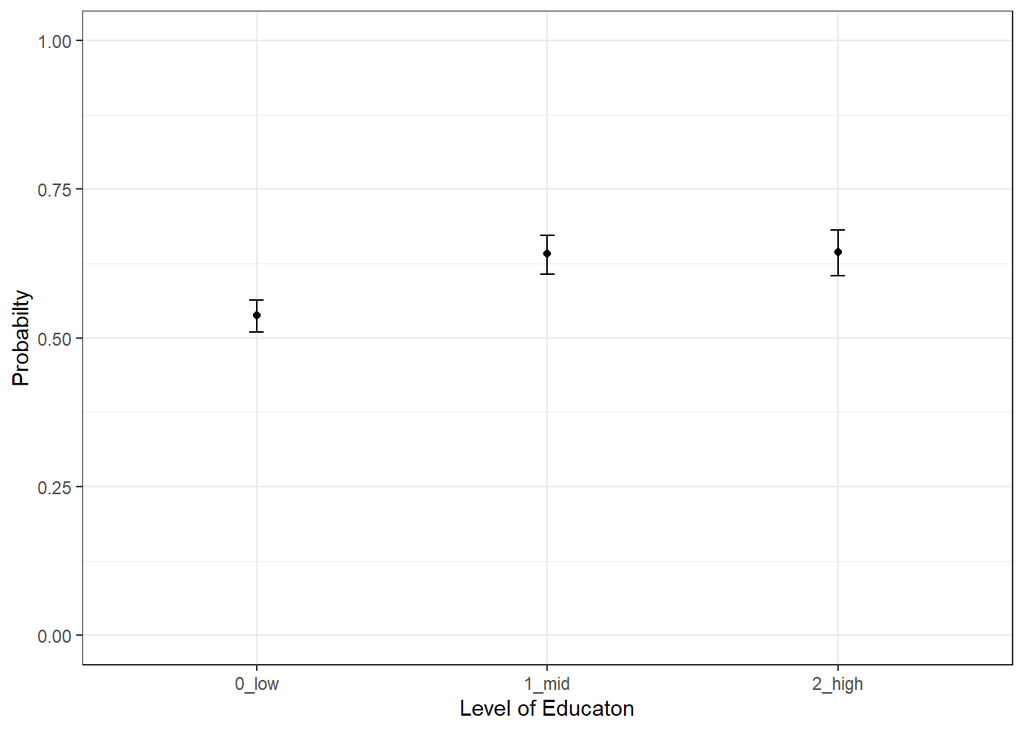

```r
# our model has 5 components
x <- cbind(1, mean(SUBSET02$AGE), prop.table(table(SUBSET02$Gender))[2],c(0,1,0), c(0,0,1))

# simulate parameter values from the multivariate normal distribution, 1000 draws
BETA.SIM <- mvrnorm(1000, BETA,COVVAR)

# use some matrix algebra to calculate to systematic component for each draw
xb <- x %*% t(BETA.SIM)


#for each draw get prediced probability
p <- 1/(1 + exp(-xb))


#get the .5 and .95 confidence intervals for each value in the sequence for V3
predicted.prob <- apply(p,1,quantile, probs = c(.05,.5,.95))

#collect the results in a data frame for plotting in ggplot2
dat <- data.frame(x = c("0_low", "1_mid", "2_high"), lower = predicted.prob[1,], middle = predicted.prob[2,], upper = predicted.prob[3,])


#plot the results with ggplot2
plot <- ggplot(dat, aes(x = x)) +
  geom_point(aes(y=middle)) +
  geom_errorbar(aes(ymin=lower, ymax=upper), width=.05) +
  ylim(0,1) +
  ylab("Probabilty")+
  xlab("Level of Educaton") +
  theme_bw()

plot
```

### 3.3.2 Interaction between two categorical variables

Now we will show you an example for when you have an interaction between two categorical variables. We will consider an interaction between Gender and Education.

```r
# For calculation purposes it is better to first create the interaction and then insert it into the model:

SUBSET02$Gen_EDU <- SUBSET02$Gender:SUBSET02$EDU_C
OUTPUT04 <- glm(DEP ~ AGE + Gen_EDU, data=SUBSET02, family=binomial())
summary(OUTPUT04)
```

```
##
## Call:
## glm(formula = DEP ~ AGE + Gen_EDU, family = binomial(), data = SUBSET02)
##
## Deviance Residuals:
##     Min       1Q   Median       3Q      Max
## -2.1275  -1.0418   0.6405   0.9416   1.9218
##
## Coefficients:
##                         Estimate Std. Error z value Pr(>|z|)
## (Intercept)             1.891416   0.173511  10.901  < 2e-16 ***
## AGE                    -0.039626   0.002847 -13.919  < 2e-16 ***
## Gen_EDU0_male:1-mid     0.197160   0.148686   1.326  0.18484
## Gen_EDU0_male:2-high    0.364393   0.173966   2.095  0.03620 *
## Gen_EDU1_female:0-low   0.370449   0.123053   3.010  0.00261 **
## Gen_EDU1_female:1-mid   1.054440   0.160816   6.557  5.5e-11 ***
## Gen_EDU1_female:2-high  0.886344   0.164787   5.379  7.5e-08 ***
## ---
## Signif. codes:  0 '***' 0.001 '**' 0.01 '*' 0.05 '.' 0.1 ' ' 1
##
## (Dispersion parameter for binomial family taken to be 1)
##
##     Null deviance: 3261.5  on 2396  degrees of freedom
## Residual deviance: 2886.9  on 2390  degrees of freedom
## AIC: 2900.9
##
## Number of Fisher Scoring iterations: 4
```

```r
# Again we get the components necessary for the simulation

BETA <- coef(OUTPUT04)
COVVAR <- vcov(OUTPUT04)

# Again we assign one value for each coefficient in the model (we want 6 predicted probabilities). Age we will keep at the mean and we will set one linear combination for each of the interaction terms.

x <- cbind(1, mean(SUBSET02$AGE), c(0,1,0,0,0,0),c(0,0,1,0,0,0), c(0,0,0,1,0,0),c(0,0,0,0,1,0), c(0,0,0,0,0,1) )

#simulate parameter values from the multivariate normal distribution, 1000 draws

BETA.SIM <- mvrnorm(1000, BETA,COVVAR)

#use some matrix algebra to calculate the systematic component for each draw
xb <- x %*% t(BETA.SIM)

#for each draw get prediced probability
p <- 1/(1 + exp(-xb))

#get the .5 and .95 confidence intervals for each value in the sequence for V3
predicted.prob <- apply(p,1,quantile, probs = c(.05,.5,.95))

#collect the results in a data frame for plotting in ggplot2
dat <- data.frame(x = c("male:low", "male:mid", "male:high","female:low", "female:mid", "female:high" ), lower = predicted.prob[1,], middle = predicted.prob[2,], upper = predicted.prob[3,], Gender=c(rep("male",3),rep("female",3)), Education=c("0_low", "1_mid", "2_high","0_low", "1_mid", "2_high"))


levels(dat$Gender)
```

```
## [1] "female" "male"
```

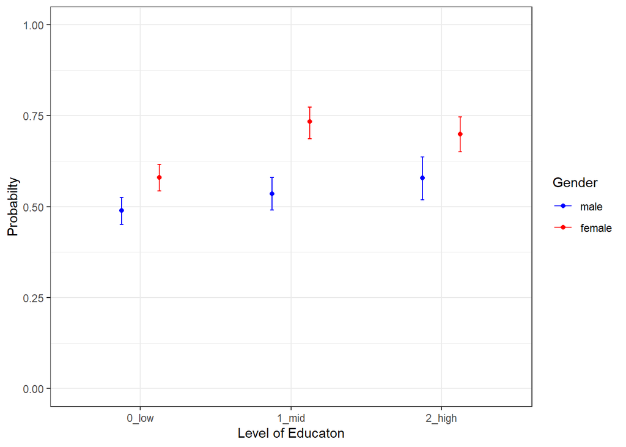

```r
# you can reorder the variables so they are like you want: if we would like to compare gender

dat$Gender = factor(dat$Gender, levels(dat$Gender)[c(2,1)])

# you can also set different colors manually
plot <- ggplot(dat, aes(x = Education, color=Gender)) +
  geom_point(aes(y=middle, color=Gender), position=position_dodge(width=0.5)) +
  geom_errorbar(aes(ymin=lower, ymax=upper, color=Gender), width=.05, position=position_dodge(width=0.5)) +
  ylim(0,1) +
  ylab("Probabilty")+
  xlab("Level of Educaton") +
  scale_color_manual(values=c("blue", "red")) +
  theme_bw()

plot
```

### 3.3.3 Interaction of a continuous and a categorical variable

As a final example we will interact age (continuous) and gender.

```r
# In this case it is better to include the interaction directly in the model

OUTPUT05 <- glm(DEP ~ Gender:AGE + EDU_C, data=SUBSET02, family=binomial())
summary(OUTPUT05)
```

```
##
## Call:
## glm(formula = DEP ~ Gender:AGE + EDU_C, family = binomial(),
##     data = SUBSET02)
##
## Deviance Residuals:
##     Min       1Q   Median       3Q      Max
## -1.9798  -1.0543   0.6583   0.9309   2.0421
##
## Coefficients:
##                     Estimate Std. Error z value Pr(>|z|)
## (Intercept)         2.075238   0.167684  12.376  < 2e-16 ***
## EDU_C1-mid          0.434450   0.111125   3.910 9.25e-05 ***
## EDU_C2-high         0.466486   0.121510   3.839 0.000123 ***
## Gender0_male:AGE   -0.044751   0.003037 -14.734  < 2e-16 ***
## Gender1_female:AGE -0.035089   0.002888 -12.152  < 2e-16 ***
## ---
## Signif. codes:  0 '***' 0.001 '**' 0.01 '*' 0.05 '.' 0.1 ' ' 1
##
## (Dispersion parameter for binomial family taken to be 1)
##
##     Null deviance: 3261.5  on 2396  degrees of freedom
## Residual deviance: 2894.6  on 2392  degrees of freedom
## AIC: 2904.6
##
## Number of Fisher Scoring iterations: 4
```

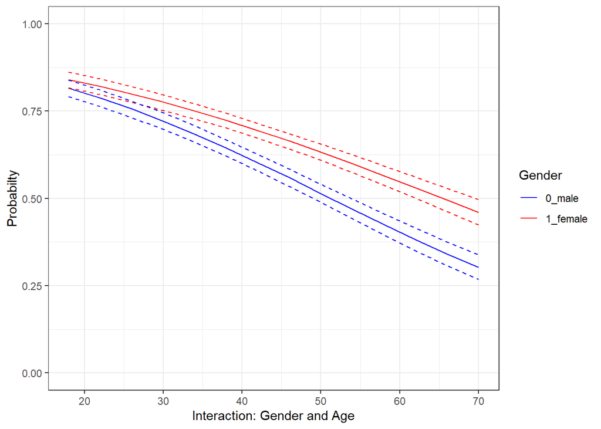

```r
# Again we get the components necessary for the simulation

BETA <- coef(OUTPUT05)
COVVAR <- vcov(OUTPUT05)

# Again we assign one value for each coefficient in the model. The education variable will be fixed at the proportions of the mid and high category. For age we want to obtain the predicted probabilities of ages 18 to 70 by steps of 4 (18, 22, 26,.., 70). Since we are considering different age parameters by gender we have to set the age parameter to 0 for the coefficient of males when we are calculating for females and vice versa.

x <- cbind(1, prop.table(table(SUBSET02$EDU_C))[2], prop.table(table(SUBSET02$EDU_C))[3], c(seq(18,70,4),rep(0,14)),c(rep(0,14),seq(18,70,4)) )


#simulate parameter values from the multivariate normal distribution, 1000 draws

BETA.SIM <- mvrnorm(1000, BETA,COVVAR)

#use some matrix algebra to calculate to systematic component for each draw
xb <- x %*% t(BETA.SIM)


#for each draw get prediced probability
p <- 1/(1 + exp(-xb))


#get the .5 and .95 confidence intervals for each value in the sequence for V3
predicted.prob <- apply(p,1,quantile, probs = c(.05,.5,.95))

#collect the results in a data frame for plotting in ggplot2
dat <- data.frame(x = c(paste0("0_m:", seq(18,70,4)), paste0("1_f:", seq(18,70,4)) ), lower = predicted.prob[1,], middle = predicted.prob[2,], upper = predicted.prob[3,], Gender=c(rep("0_male",14), rep("1_female", 14)), Age=c(seq(18,70,4),seq(18,70,4)))

plot <- ggplot(dat, aes(x = Age, group=Gender)) +
    geom_line(aes(color=Gender, y=middle)) +
    geom_line(aes(color=Gender, y=lower), linetype = 2) +
    geom_line(aes(color=Gender, y=upper), linetype = 2) +
    ylim(0,1) +
    ylab("Probabilty")+
    xlab("Interaction: Gender and Age") +
    scale_color_manual(values=c("blue", "red"))+
                         theme_bw()

plot
```

# 4 Appendix: From the LN(ODDS) to the predicted probabilities

$LN(\frac{P(x)}{1-P(x)})=b_0 + b_1x_1$

To simplify we will replace $b_0 + b_1x_1$ by $bx$ but it is equivalent to have the full equation:

$LN(\frac{P(x)}{1-P(x)})=bx$

$LN(P(x))-LN(1-P(x))=bx$

$LN(P(x))=bx + LN(1-P(x))$

$P(x)=e^{bx + LN(1-P(x))}$

$P(x)=e^{bx}*e^{LN(1-P(x))}$

$P(x)=e^{bx}(1-P(x))$

$P(x)=e^{bx}-e^{bx}*P(x)$

$P(x)+e^{bx}*P(x)=e^{bx}$

$P(x)(1+e^{bx})=e^{bx}$

$P(x)=\frac{e^{bx}}{1+e^{bx}}$

$P(x)=\frac{e^{bx}}{1+e^{bx}}*\frac{e^-bx}{e^-bx}$

$P(x)=\frac{1}{1+e^{-bx}}$

# 5 Acknowledgment

For helpful comments and language editing, I thank Lena Klein. I also thank Florien Kruse who commented on an earlier version of this manuscript. All remaining errors are my own. (I am always happy to receive comments and suggestions on this document: kreyenfeld@hertie-school.org).

# 6 References

King, G., Tomz, M., and Wittenberg, J. (2000). “Making the Most of Statistical Analyses: Improving Interpretation and Presentation.” *American Journal of Political Science*, 44(2): 341–355.

The PolStat Feed (2011). Simulating Confidence Intervals, retrieved from: https://www.r-bloggers.com/simulating-confidence-intervals/